# Sales

## Introduction

Data analysis has proven to be very effective in sales. This is because we can extract key performance indicators (KPIs) to make smarter decisions. This saves time, resources, and money.Sales data analysis can cover many aspects (sales, production, customer experience, employee efficiency). The goal of this project is to analyze data from a sales records database for scale model cars and extract information for decision-making. Good analysis starts with questions. Below are the questions we want to answer for this project

- Which five products have generated the highest revenue for our company, and what percentage of total revenue do they account for?
- Which products should we order more of or less of for an effective inventory management?
- How should we tailor marketing and communication strategies to customer behaviors?
- How many new customers are arriving each month? If there's a decline in new customer arrivals, how much could we spend on marketing to increase customer arrivals?
- How much is the Customer Lifetimevalue(LTV)?

The description of the database can be found [here](https://github.com/Niranjin/SQL-Projects/tree/main#readme)

### Installing packages and loading the database

```python
import pandas as pd
import sqlite3
import matplotlib.pyplot as plt
conn = sqlite3.connect('stores.db')
!pip install ipython-sql
%load_ext sql
%sql sqlite:///stores.db
```

### function for creating a bar plot

```python
def create_bar_plot(df, x, y, primary_title, secondary_title):
    """
    Function to create a horizontal bar plot.

    Parameters:
        df (DataFrame): DataFrame containing the data for the plot.
        x (str): Column name from df to be plotted on the x-axis.
        y (str): Column name from df to be plotted on the y-axis.
        primary_title (str): Title for the plot, positioned above the secondary title.
        secondary_title (str): Subtitle providing additional context or information about the plot.

    Returns:
        None (Displays the generated plot).
    """
    # Create figure and axis objects
    fig, ax = plt.subplots(figsize=(10, 6))

    # Generate horizontal bar plot
    ax.barh(df[x], df[y], color='#FBCEB1')

    # Set primary title
    plt.suptitle(primary_title, x=0.35, y=1.05, fontsize=19, fontweight='bold')

    # Set secondary title
    plt.title(secondary_title, x=0.35, y=1.095, fontsize=14)

    # Customize axis appearance and layout
    ax.xaxis.tick_top()  # Place x-axis ticks on top
    ax.set_ylabel(None)  # No label for y-axis
    ax.tick_params(top=False, left=False)  # Remove ticks on top and left sides
    ax.tick_params(axis='x', colors='grey')  # Set x-axis tick color
    ax.tick_params(axis='both', labelsize=12)  # Set tick label size
    ax.set_xticks([25000, 75000, 125000])  # Define specific x-tick locations
    ax.axvline(x=75000, ymin=0.05, color='blue', alpha=0.05)  # Add vertical line as a visual reference

    # Remove spines (axes lines) on all sides for cleaner appearance
    for location in ['left', 'right', 'bottom', 'top']:
        ax.spines[location].set_visible(False)

    # Display the plot
    plt.show()
```

### Exploring the data

```python
%%sql
SELECT * FROM customers
limit 5;
```

```
 * sqlite:///stores.db
Done.
```

| customerNumber | customerName | contactLastName | contactFirstName | phone | addressLine1 | addressLine2 | city | state | postalCode | country | salesRepEmployeeNumber | creditLimit |
| --- | --- | --- | --- | --- | --- | --- | --- | --- | --- | --- | --- | --- |
| 103 | Atelier graphique | Schmitt | Carine | 40.32.2555 | 54, rue Royale | None | Nantes | None | 44000 | France | 1370 | 21000 |
| 112 | Signal Gift Stores | King | Jean | 7025551838 | 8489 Strong St. | None | Las Vegas | NV | 83030 | USA | 1166 | 71800 |
| 114 | Australian Collectors, Co. | Ferguson | Peter | 03 9520 4555 | 636 St Kilda Road | Level 3 | Melbourne | Victoria | 3004 | Australia | 1611 | 117300 |
| 119 | La Rochelle Gifts | Labrune | Janine | 40.67.8555 | 67, rue des Cinquante Otages | None | Nantes | None | 44000 | France | 1370 | 118200 |
| 121 | Baane Mini Imports | Bergulfsen | Jonas | 07-98 9555 | Erling Skakkes gate 78 | None | Stavern | None | 4110 | Norway | 1504 | 81700 |

```python
%%sql
select * from offices
limit 5;
```

```
 * sqlite:///stores.db
Done.
```

| officeCode | city | phone | addressLine1 | addressLine2 | state | country | postalCode | territory |
| --- | --- | --- | --- | --- | --- | --- | --- | --- |
| 1 | San Francisco | +1 650 219 4782 | 100 Market Street | Suite 300 | CA | USA | 94080 | NA |
| 2 | Boston | +1 215 837 0825 | 1550 Court Place | Suite 102 | MA | USA | 02107 | NA |
| 3 | NYC | +1 212 555 3000 | 523 East 53rd Street | apt. 5A | NY | USA | 10022 | NA |
| 4 | Paris | +33 14 723 4404 | 43 Rue Jouffroy D'abbans | None | None | France | 75017 | EMEA |
| 5 | Tokyo | +81 33 224 5000 | 4-1 Kioicho | None | Chiyoda-Ku | Japan | 102-8578 | Japan |

### Table info

This SQL code generates a summary of the tables in the database, including the table name, the number of attributes (columns) each table has, and the total number of rows in each table. It uses the `UNION ALL` operator to combine the results from multiple `SELECT` queries into a single result set. Each `SELECT` query retrieves information for a specific table in the database, such as Customers, Products, Orders, etc. The results are presented as a table with columns for table name, number of attributes, and number of rows.

```python
%%sql
-- This SQL code provides a summary of tables in the database, including their attributes and row counts.
-- It combines the results of multiple SELECT queries using the UNION ALL operator.

-- Query for Customers table
SELECT 'Customers' AS table_name,
       13 AS number_of_attributes,
       COUNT(*) AS number_of_rows
  FROM Customers

UNION ALL

-- Query for Products table
SELECT 'Products' AS table_name,
       9 AS number_of_attributes,
       COUNT(*) AS number_of_rows
  FROM Products

UNION ALL

-- Query for ProductLines table
SELECT 'ProductLines' AS table_name,
       4 AS number_of_attributes,
       COUNT(*) AS number_of_rows
  FROM ProductLines

UNION ALL

-- Query for Orders table
SELECT 'Orders' AS table_name,
       7 AS number_of_attributes,
       COUNT(*) AS number_of_rows
  FROM Orders

UNION ALL

-- Query for OrderDetails table
SELECT 'OrderDetails' AS table_name,
       5 AS number_of_attributes,
       COUNT(*) AS number_of_rows
  FROM OrderDetails

UNION ALL

-- Query for Payments table
SELECT 'Payments' AS table_name,
       4 AS number_of_attributes,
       COUNT(*) AS number_of_rows
  FROM Payments

UNION ALL

-- Query for Employees table
SELECT 'Employees' AS table_name,
       8 AS number_of_attributes,
       COUNT(*) AS number_of_rows
  FROM Employees

UNION ALL

-- Query for Offices table
SELECT 'Offices' AS table_name,
       9 AS number_of_attributes,
       COUNT(*) AS number_of_rows
  FROM Offices;
```

```
 * sqlite:///stores.db
Done.
```

| table_name | number_of_attributes | number_of_rows |
| --- | --- | --- |
| Customers | 13 | 122 |
| Products | 9 | 110 |
| ProductLines | 4 | 7 |
| Orders | 7 | 326 |
| OrderDetails | 5 | 2996 |
| Payments | 4 | 273 |
| Employees | 8 | 23 |
| Offices | 9 | 7 |

#### What are the products that generated the highest revenue for our company, and what percentage of total revenue do they account for?

The revenue generated from each product can be determined by computing the difference between the selling price (priceEach) and the buying price (Buyprice).

```python
# SQL query to calculate total revenue and revenue percentage for each product
query = '''
WITH total_revenue_table AS (
    -- Calculate total revenue by summing the difference between total sales revenue and total cost for all products
    SELECT
        SUM((o.quantityordered * o.priceeach) - (o.quantityordered * p.buyprice)) AS total_revenue
    FROM
        orderdetails o
    JOIN
        products p ON o.productcode = p.productcode
),
revenue_by_product AS (
    -- Calculate revenue for each product by summing the difference between sales revenue and cost for each product
    SELECT
        p.productname,
        p.productcode,
        SUM((o.quantityordered * o.priceeach) - (o.quantityordered * p.buyprice)) AS revenue
    FROM
        products p
    JOIN
        orderdetails o ON o.productcode = p.productcode
    GROUP BY
        p.productcode, p.productname
)
-- Select product name, product code, revenue, and revenue percentage for each product
SELECT
    rb.productname,
    rb.productcode,
    rb.revenue,
    -- Calculate revenue percentage for each product
    ROUND((rb.revenue / trt.total_revenue) * 100, 2) AS revenue_percent
FROM
    revenue_by_product rb
JOIN
    total_revenue_table trt ON 1 = 1
-- Order the results by revenue in descending order
ORDER BY
    rb.revenue DESC;
'''

# Execute the SQL query and fetch the results into a DataFrame
df = pd.read_sql_query(query, conn)

# Extract the top five products with the highest revenue
top_five_products = df.head(5)
```

```python
# Prepare data for pie plot
top_ten_products = df.head(10)  # Assuming 'df' contains the data of the top five products
other_revenue = df['revenue'].sum() - top_five_products['revenue'].sum()

# Calculate percentages
revenue_percentages = top_ten_products['revenue'] / df['revenue'].sum() * 100
other_percentage = (other_revenue / df['revenue'].sum()) * 100

# Create labels for the pie plot
labels = top_ten_products['productname'].tolist()
labels.append('Other')

# Create data for the pie plot
sizes = revenue_percentages.tolist()
sizes.append(other_percentage)
colors = colors = ['lightcoral', 'lightskyblue', 'lightgreen', 'lightyellow', 'lightgrey', 'gold', 'orange', 'lightpink', 'lightseagreen', 'lavender','lightgrey']
print(top_ten_products['revenue'].sum())
```

```
814028.88
```

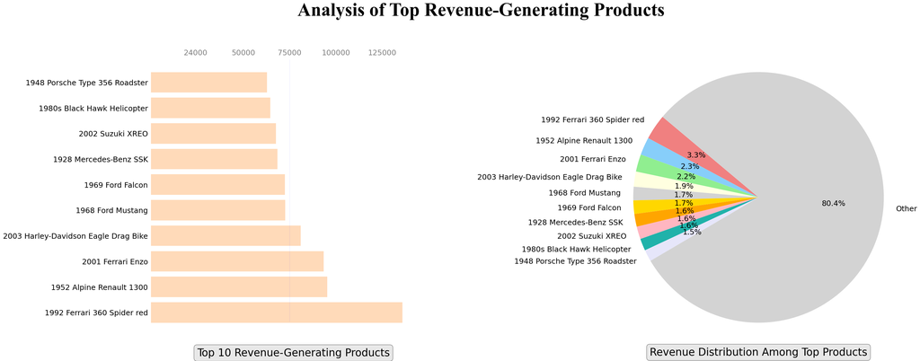

```python
# Create subplots with appropriate figure size and spacing
fig, (ax1, ax2) = plt.subplots(1, 2, figsize=(32, 12), gridspec_kw={'wspace': 0.8})

# Plot the horizontal bar plot for top revenue-generating products
ax1.barh(top_ten_products['productname'], top_ten_products['revenue'], color='#FFDAB9')

# Plot the pie chart for revenue distribution among top products
ax2.pie(sizes, labels=labels, colors=colors, autopct='%1.1f%%', startangle=140, textprops={'fontsize': 18})

# Set main title and adjust position
main_title = 'Analysis of Top Revenue-Generating Products'
ax1.set_title(main_title, x=1.25, y=1.15, fontsize=45, weight='bold', fontname='Times New Roman')

# Set subtitles and adjust positions with boxes around them
sub1 = "Top 10 Revenue-Generating Products"
sub2 = "Revenue Distribution Among Top Products"
ax1.text(s=sub1, x=25000.5, y=-1.7, fontsize=25, bbox=dict(facecolor='lightgrey', alpha=0.5, edgecolor='black', boxstyle='round,pad=0.3'))
ax2.set_title(sub2, x=0.5, y=-0.082, fontsize=25, bbox=dict(facecolor='lightgrey', alpha=0.5, edgecolor='black', boxstyle='round,pad=0.3'))

# Adjust axes and ticks for better readability
ax1.xaxis.tick_top()
ax1.set_ylabel(None)
ax1.tick_params(top=False, left=False)
ax1.tick_params(axis='x', colors='grey')
ax1.tick_params(axis='both', labelsize=18)
ax1.set_xticks([24000, 50000, 75000, 100000, 125000])
ax1.axvline(x=75000, ymin=0.05, color='blue', alpha=0.05)
ax2.axis('equal')

# Hide spines for aesthetic purposes
for ax in [ax1, ax2]:
    for location in ['left', 'right', 'bottom', 'top']:
        ax.spines[location].set_visible(False)

# Display the plot
plt.show()
```

### Which products should we order more of or less of for an effective inventory management?

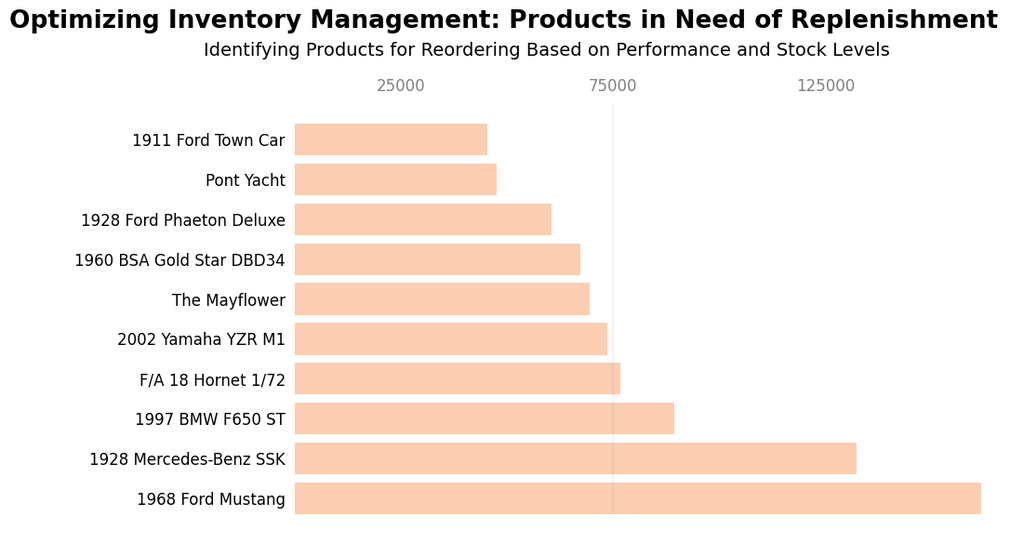

```python
# SQL Query to Find Products with Low Stock and Their Performance

query = '''
WITH
-- Common Table Expression (CTE) to Find Products with Low Stock
low_stock_table AS (
    SELECT
        productCode,
        -- Calculate the ratio of quantity ordered to quantity in stock for each product
        ROUND(SUM(quantityOrdered) * 1.0 / (
            SELECT quantityInStock FROM products p WHERE od.productCode = p.productCode), 2) AS low_stock
    FROM
        orderdetails od
    GROUP BY
        productCode
    ORDER BY
        low_stock DESC
    LIMIT 10
)

-- Main Query to Fetch Product Details and Performance for Low Stock Products
SELECT
    productCode,
    -- Subquery to fetch the product name based on the product code
    (SELECT productname FROM products p WHERE od.productcode = p.productcode) AS product_name,
    -- Calculate the total performance (quantity ordered * price each) for each product
    SUM(quantityOrdered * priceEach) AS prod_perf
FROM
    orderdetails od
-- Filter products based on those in the low_stock_table
WHERE
    productCode IN (SELECT productCode FROM low_stock_table)
GROUP BY
    productCode
-- Order the results by product performance in descending order
ORDER BY
    prod_perf DESC
LIMIT 10;
'''

# Execute the SQL query and fetch results into a pandas DataFrame
low_stock = pd.read_sql_query(query, conn)

# Display the DataFrame containing products with low stock and their performance using matplotlib
create_bar_plot(low_stock,'product_name','prod_perf','Optimizing Inventory Management: Products in Need of Replenishment','Identifying Products for Reordering Based on Performance and Stock Levels')
```

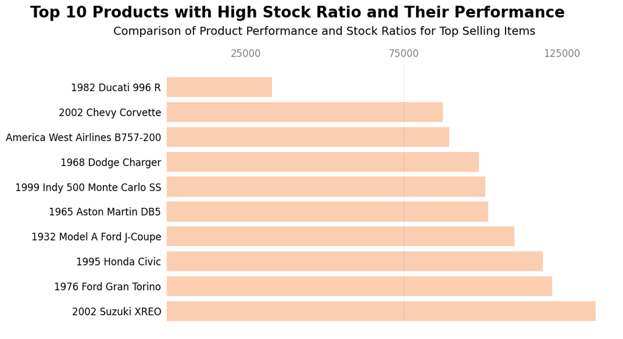

```python
# SQL Query to Find Products in high stock  with low Performance

query = '''
WITH
-- Common Table Expression (CTE) to Find Products with high Stock
high_stock_table AS (
    SELECT
        productCode,
        -- Calculate the ratio of quantity ordered to quantity in stock for each product
        ROUND(SUM(quantityOrdered) * 1.0 / (
            SELECT quantityInStock FROM products p WHERE od.productCode = p.productCode), 2) AS high_stock
    FROM
        orderdetails od
    GROUP BY
        productCode
    ORDER BY
        high_stock ASC
    LIMIT 10
)

-- Main Query to Fetch Product Details and Performance for Low Stock Products
SELECT
    productCode,
    -- Subquery to fetch the product name based on the product code
    (SELECT productname FROM products p WHERE od.productcode = p.productcode) AS product_name,
    -- Calculate the total performance (quantity ordered * price each) for each product
    SUM(quantityOrdered * priceEach) AS prod_perf
FROM
    orderdetails od
-- Filter products based on those in the high_stock_table
WHERE
    productCode IN (SELECT productCode FROM high_stock_table)
GROUP BY
    productCode
-- Order the results by product performance in asc order
ORDER BY
    prod_perf desc
'''

# Execute the SQL query and fetch results into a pandas DataFrame
high_stock = pd.read_sql_query(query, conn)

# Display the DataFrame containing products with low stock and their performance using matplotlib
create_bar_plot(high_stock,'product_name','prod_perf',"Top 10 Products with High Stock Ratio and Their Performance",'Comparison of Product Performance and Stock Ratios for Top Selling Items')
```

### How should we tailor marketing and communication strategies to customer behaviors?

This involves categorizing customers: finding the VIP (very important person) customers and those who are less engaged.

- VIP customers bring in the most profit for the store.
- Less-engaged customers bring in less profit.

For example, we could organize some events to drive loyalty for the VIPs and launch a campaign or give out offer coupons for the less engaged.

1.VIP customers

```python
%%sql
WITH

money_in_by_customer_table AS (
SELECT o.customerNumber, SUM(quantityOrdered * (priceEach - buyPrice)) AS revenue
  FROM products p
  JOIN orderdetails od
    ON p.productCode = od.productCode
  JOIN orders o
    ON o.orderNumber = od.orderNumber
 GROUP BY o.customerNumber
)

SELECT contactFirstName||' '||contactLastName as customer_name,  city, country, mc.revenue
  FROM customers c
  JOIN money_in_by_customer_table mc
    ON mc.customerNumber = c.customerNumber
 ORDER BY mc.revenue DESC
 LIMIT 5;
```

```
 * sqlite:///stores.db
Done.
```

| customer_name | city | country | revenue |
| --- | --- | --- | --- |
| Diego Freyre | Madrid | Spain | 326519.66 |
| Susan Nelson | San Rafael | USA | 236769.39 |
| Jeff Young | NYC | USA | 72370.09 |
| Peter Ferguson | Melbourne | Australia | 70311.07 |
| Janine Labrune | Nantes | France | 60875.3 |

2.Less engaging customers

```python
%%sql
WITH

money_in_by_customer_table AS (
SELECT o.customerNumber, SUM(quantityOrdered * (priceEach - buyPrice)) AS revenue
  FROM products p
  JOIN orderdetails od
    ON p.productCode = od.productCode
  JOIN orders o
    ON o.orderNumber = od.orderNumber
 GROUP BY o.customerNumber
)

SELECT contactFirstName||' '||contactLastName as customer_name,  city, country, round(mc.revenue,2) as revenue
  FROM customers c
  JOIN money_in_by_customer_table mc
    ON mc.customerNumber = c.customerNumber
 ORDER BY mc.revenue asc
 LIMIT 5;
```

```
 * sqlite:///stores.db
Done.
```

| customer_name | city | country | revenue |
| --- | --- | --- | --- |
| Mary Young | Glendale | USA | 2610.87 |
| Leslie Taylor | Brickhaven | USA | 6586.02 |
| Franco Ricotti | Milan | Italy | 9532.93 |
| Carine Schmitt | Nantes | France | 10063.8 |
| Thomas Smith | London | UK | 10868.04 |

### How many new customers are arriving each month? If there's a decline in new customer arrivals, how much could we spend on marketing to increase customer arrivals?

```python
# SQL query to calculate the proportion of new customers and their total contribution to revenue on a monthly basis
query = '''
-- Common Table Expressions (CTEs) to prepare data for analysis

-- CTE to compute the year and month from payment dates
WITH payment_with_year_month_table AS (
    SELECT *,
           CAST(SUBSTR(paymentDate, 1,4) AS INTEGER)*100 + CAST(SUBSTR(paymentDate, 6,7) AS INTEGER) AS year_month
      FROM payments p
),

-- CTE to calculate the number of customers and total revenue for each month
customers_by_month_table AS (
    SELECT p1.year_month, COUNT(*) AS number_of_customers, SUM(p1.amount) AS total
      FROM payment_with_year_month_table p1
     GROUP BY p1.year_month
),

-- CTE to compute the number of new customers and their total revenue contribution for each month
new_customers_by_month_table AS (
    SELECT p1.year_month,
           COUNT(*) AS number_of_new_customers,
           SUM(p1.amount) AS new_customer_total,
           (SELECT number_of_customers
              FROM customers_by_month_table c
            WHERE c.year_month = p1.year_month) AS number_of_customers,
           (SELECT total
              FROM customers_by_month_table c
             WHERE c.year_month = p1.year_month) AS total
      FROM payment_with_year_month_table p1
     WHERE p1.customerNumber NOT IN (SELECT customerNumber
                                       FROM payment_with_year_month_table p2
                                      WHERE p2.year_month < p1.year_month)
     GROUP BY p1.year_month
)

-- Main query to fetch the year_month, proportion of new customers, and proportion of revenue from new customers
SELECT year_month,
       ROUND(number_of_new_customers * 100 / number_of_customers, 1) AS number_of_new_customers_props,
       ROUND(new_customer_total * 100 / total, 1) AS new_customers_total_props
  FROM new_customers_by_month_table;
'''

# Execute the SQL query and store the results in a pandas DataFrame
year_month_data = pd.read_sql_query(query, conn)

# Convert the year_month column to a string data type for further processing
year_month_data['year_month'] = year_month_data['year_month'].astype(str)
```

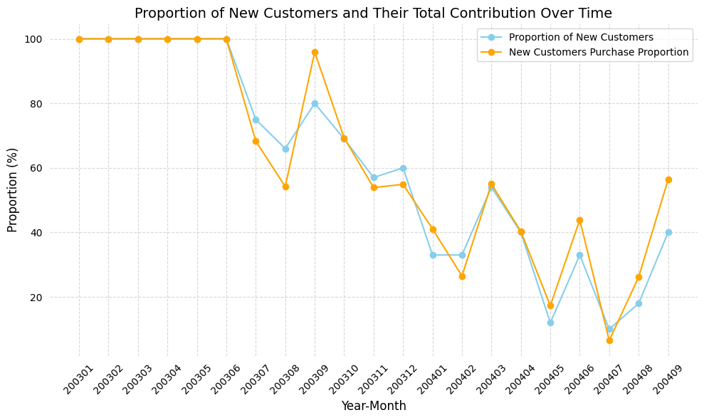

```python
# Create a figure for the plot
plt.figure(figsize=(10, 6))

# Plotting the proportion of new customers over time
plt.plot(year_month_data['year_month'], year_month_data['number_of_new_customers_props'], marker='o', color='skyblue', label='Proportion of New Customers')

# Plotting the proportion of new customers' purchases over time
plt.plot(year_month_data['year_month'], year_month_data['new_customers_total_props'], marker='o', color='orange', label='New Customers Purchase Proportion')

# Adding labels and title
plt.xlabel('Year-Month', fontsize=12)  # X-axis label
plt.ylabel('Proportion (%)', fontsize=12)  # Y-axis label
plt.title('Proportion of New Customers and Their Total Contribution Over Time', fontsize=14)  # Plot title
plt.xticks(rotation=45)  # Rotate x-axis labels for better readability
plt.legend(fontsize=10)  # Display legend with specified font size

# Hide ticks on the bottom and left axes
plt.gca().tick_params(bottom=False, left=False)

# Hide spines (borders) of the plot
for location in ['left', 'right', 'bottom', 'top']:
    plt.gca().spines[location].set_visible(False)

# Add grid lines
plt.grid(True, linestyle='--', alpha=0.5)

# Adjust layout and display the plot
plt.tight_layout()
plt.show()
```

#### Key findings:-

- The number of clients has been decreasing since 2003, and in 2004, we had the lowest values. The year 2005, which is present in the database as well, isn't present in the table above, this means that the store has not had any new customers since September of 2004. Hence it is crucial to spend some money on marketing to acquire new customers.
- To determine how much money we can spend acquiring new customers, we can compute the *Customer Lifetime Value (LTV)*, which represents the average amount of money a customer generates. We can then determine how much we can spend on marketing

### How much is the Customer Lifetimevalue(LTV)?

```python
%%sql
WITH
money_in_by_customer_table AS (
SELECT o.customerNumber, SUM(quantityOrdered * (priceEach - buyPrice)) AS revenue
  FROM products p
  JOIN orderdetails od
    ON p.productCode = od.productCode
  JOIN orders o
    ON o.orderNumber = od.orderNumber
 GROUP BY o.customerNumber
)

SELECT '$'||ROUND(AVG(mc.revenue),2) AS LTV
  FROM money_in_by_customer_table mc;
```

```
 * sqlite:///stores.db
Done.
```

| LTV |
| --- |
| $39039.59 |

This means that each customer contributes approximately $39,039.59 to the company's revenue over their entire relationship with the business. This metric is crucial for understanding the long-term value that each customer brings to the company and can inform decisions related to customer acquisition, retention, and marketing strategies.

# Summary

At the conclusion of our thorough analysis of the sales records for scale model cars, we have distilled our findings into the following key points. These insights are pivotal for strategizing future business operations, inventory management, marketing approaches, and customer relationship enhancements.

**2. Inventory Management Insights:**

- **Products to Order More Of:**  
  Based on sales velocity and customer demand trends, car models such as 1968 Ford mustang and Mercedes Benz are identified as high priority for restocking.
- **Products to Scale Back On:**  
  Conversely, models like Ducati and chevy Corvette have been identified for reduced ordering due to lower sales performance and oversaturation in inventory.

**3. Tailored Marketing and Communication Strategies:**

- **Customer Behavior Insights:**  
  Our analysis reveals VIP customers and less-engaging customers suggesting a need to tailor our marketing strategies to these specific customers to gain loyalty and to foster stronger connections.
- **Recommended Marketing Adjustments:**
  - The VIP customers of our store and we could give exclusive VIP discounts and to invite them to elite meetings, send personalized gifts, and offer priority services like expedited shipping and dedicated customer support lines. This demonstrate that their business is important to us and that we prioritize their needs.
  - For less engaged customers, we aim to reignite interest. We could offer reactivation discounts, personalized recommendations, and surprise offers. Engaging campaigns, feedback collection, and targeted promotions help re-engage them. Exclusive content and dedicated support enhance their experience thereby regaining their trust in our producs.

**4. New Customer Acquisition Trends:**

**5. Customer Lifetime Value (LTV):**

- **Average LTV:**  
  The average Customer Lifetime Value calculated through our analysis stands at $39039, providing crucial insight into revenue potential from each customer over their relationship with our business.

**6. Strategic Recommendations:**

- In light of these findings, strategic recommendations include optimizing inventory for high-demand products, reallocating marketing budgets to target both high-value customers and potential new markets, and focusing on enhancing customer experiences to increase the average LTV.

**Conclusion:**

These key findings underscore the potential for significant improvements across various facets of our business. By strategically addressing the areas highlighted, we can aim for enhanced efficiency, profitability, and customer satisfaction in our operations moving forward.